# Aplicação do PSF com validação cruzada a séries de vazão naturalizada

Jerônimo Acker D’Ornellas

24/05/2021

## Objetivo

O objetivo do testePSF é realizar a aplicação do algoritmo PSF em séries hidrológicas e comparar o desempenho do algoritmo com outros métodos univariados amplamente usados para os dados das bacia hidrográficas da ONS. Neste arquivo aplicaremos a validação cruzada aos postos da ONS. A partir da validação cruzada esperamos obter uma avaliação robusta do desempenho do algoritmo PSF e também selecionar, a partir da busca de um padrão, os parâmetros ótimos.

## Pré-requisitos

Pacotes necessários:

```r
if(!require(PSF)) install.packages("PSF")
if(!require(timetk)) remotes::install_github("business-science/timetk")

pacotes <- c(
  "here",
  "usethis",
  "data.table",
  "HEobs",
  "PSF",
  "tidyverse",
  "lubridate",
  "fs",
  "checkmate",
  "xts",
  "hydroGOF",
  "ModelMetrics",
  "forecast",
  "timetk"
)
# Carregar os pacotes
easypackages::libraries(pacotes)
```

Scripts:

```r
source(here('R', 'load-data.R'))
source(here('R', 'utils.R'))
```

## Dados de vazão

Os dados importados de vazão devem ser regularmente espaçados no tempo. Esta adequação das séries diárias, se necessária, pode ser realizada com a função `complete_dates()` do pacote **`{lhmetools}`**. Assim assegura-se que todas estações possuam 1 observação por dia e sem datas faltantes.

```r
qnat_data <- qnat_dly_ons() %>%
  select(date, qnat, code_stn) %>%
  lhmetools::complete_dates(group = "code_stn")
glimpse(qnat_data)
```

```
## Rows: 2,796,267
## Columns: 3
## $ date     <date> 1931-01-02, 1931-01-03, 1931-01-04, 1931-01-05, 1931-01-06, …
## $ code_stn <dbl> 1, 1, 1, 1, 1, 1, 1, 1, 1, 1, 1, 1, 1, 1, 1, 1, 1, 1, 1, 1, 1…
## $ qnat     <dbl> NA, NA, NA, NA, NA, NA, NA, NA, NA, NA, NA, NA, NA, NA, NA, N…
```

Observam-se dados faltantes na série, então selecionaremos através da função `apply_cmonth` somente os meses com pelo menos 28 observações válidas. Para robustez da avaliação consideraremos apenas anos que atendam ao critério de disponibilidade nos 12 meses do ano e verificamos se a série é múltipla de 12 como requisito da aplicação do PSF através da função `apply_cyears`.

```r
# Média mensal das observações de vazão para todos os postos
qnat_mly <- qnat_data %>%
  apply_cmonth(., ndays_thresh = 28) %>%
  group_by(code_stn) %>%
  nest() %>%
  mutate(
    data = map(data, apply_cyears)
  )
```

## Validação cruzada aplicada ao posto 287

A validação cruzada é um método bastante utilizado não só para obter uma estimativa robusta do desempenho de um modelo, mas também para selecionar os melhores hiperparâmetros (parâmetros que são definidos antes de treinar um modelo). Este método irá ser usado na série hidrológica do posto de código 287 da ONS, o qual obtivemos o melhor desempenho utilizando a técnica de previsão PSF para os dos últimos anos da série. Com isso, buscamos obter uma estimativa mais robusta do algoritmo de previsão e selecionar valores ótimos para os parâmetros `k` e `w`.

```r
qnatmly_287 <- qnat_mly %>%
  sel_station(., 287) %>%
  unnest(cols = data) %>%
  ungroup() %>%
  select(date, qnat_obs)
summary(qnatmly_287)
```

```
##       date               qnat_obs
##  Min.   :1968-01-01   Min.   : 2788
##  1st Qu.:1980-09-23   1st Qu.: 8087
##  Median :1993-06-16   Median :17365
##  Mean   :1993-06-16   Mean   :18972
##  3rd Qu.:2006-03-08   3rd Qu.:28285
##  Max.   :2018-12-01   Max.   :54435
```

Separaremos os dados em um conjunto de treinamento e outro de teste, tal como feito anteriormente, só que dessa vez realizaremos previsões para um horizonte de 12 meses. A ideia é usar o conjunto de dados de teste após a validação cruzada para avaliar o desempenho das previsões utilizando os parâmetros selecionados.

```r
# Dados de treinamento sem o último ano
train287_qmly <- get_traindt(qnatmly_287, n_years = 1)
summary(train287_qmly)
```

```
##       date               qnat_obs
##  Min.   :1968-01-01   Min.   : 2788
##  1st Qu.:1980-06-23   1st Qu.: 8087
##  Median :1992-12-16   Median :17287
##  Mean   :1992-12-15   Mean   :18924
##  3rd Qu.:2005-06-08   3rd Qu.:28259
##  Max.   :2017-12-01   Max.   :54435
```

```r
# Dados para avaliação do PSF
test287_qmly <- get_testdt(qnatmly_287, n = 12)
summary(test287_qmly)
```

```
##       date               qnat_obs
##  Min.   :2018-01-01   Min.   : 4749
##  1st Qu.:2018-03-24   1st Qu.: 9135
##  Median :2018-06-16   Median :22404
##  Mean   :2018-06-16   Mean   :21351
##  3rd Qu.:2018-09-08   3rd Qu.:31931
##  Max.   :2018-12-01   Max.   :39355
```

Os dados de treinamento serão divididos em duas partições: treinamento e validação. Nessa forma de divisão teremos a partição de validação sempre a frente da partição de treinamento. A função `time_series_cv` do pacote `timetk` nos permite criar uma plano de amostragem começando com as observações mais atuais da série. A partir do parâmetro `assess` definimos que a partição da validação deverá ser formada de 12 meses de observações e o parâmetro `skip` fornece o número de meses que serão pulados em cada divisão. O número de divisões é selecionado pelo parâmetro `slice_limit` e um número não fixo da janela foi definido através do parâmetro `cumulative`. Aumentando o número de divisões teremos uma avaliação mais robusta do modelo, porém há um maior custo computacional.

```r
resample_qmly287 <- time_series_cv(
  data = train287_qmly,
  assess = "12 months",
  skip = "36 months",
  cumulative = TRUE,
  slice_limit = 15
)
```

```
## Using date_var: date
```

```r
# Visualização do plano de amostragem
# resample_qmly287 %>%  plot_time_series_cv_plan(date,qnat_obs, .interactive = FALSE)
```

Aplicaremos o PSF a todas as divisões do conjunto de treinamento e uma coluna é adicionada com as previsões usando a média dos parâmetros `k` e `w`.

```r
qmly287_slices <- resample_qmly287 %>%
  tk_time_series_cv_plan() %>%
  nest(date, qnat_obs) %>%
  pivot_wider(names_from = .key, values_from = data)
```

```r
# Previsões usando um horizonte de 12 meses
cv287_qmly <- qmly287_slices %>%
  mutate(
    qnat_pred = map(
      training,
      ~ psf_reprod(.x, n = 12)
    ),
    model = map(
      training,
      ~ psf_reprod(.x, n = 12, predict = FALSE)
    ),
    cvparams = map(model, get_cvpar)
  )


# Média dos parâmetros k e w (2 e 3)

# cvm_params <- round(Reduce("+", cv287_qmly[["cvparams"]])
# / length(cv287_qmly[["cvparams"]]), 0)

# opção de código mais legível
params <- cv287_qmly[["cvparams"]] %>%
  map_dfr(~.x)

cv_med_params <- params %>%
  summarise(across(c(k, w), ~ round(mean(.x))))
cv_mod_params <- params %>%
  summarise(across(c(k, w), moda))


# Adicionando  coluna com as  prevs usando parâmetros médios
cv287_qmly <- cv287_qmly %>%
  mutate(qnat_medpar_pred = map(
    training,
    ~ psf_cvparam(.x, n = 12, params = cv_med_params)
  ),
  qnat_modpar_pred = map(
    training,
    ~ psf_cvparam(.x, n = 12, params = cv_mod_params)
  ))
```

Iremos comparar o desempenho do modelo com e sem a seleção dos parâmetros pela média.

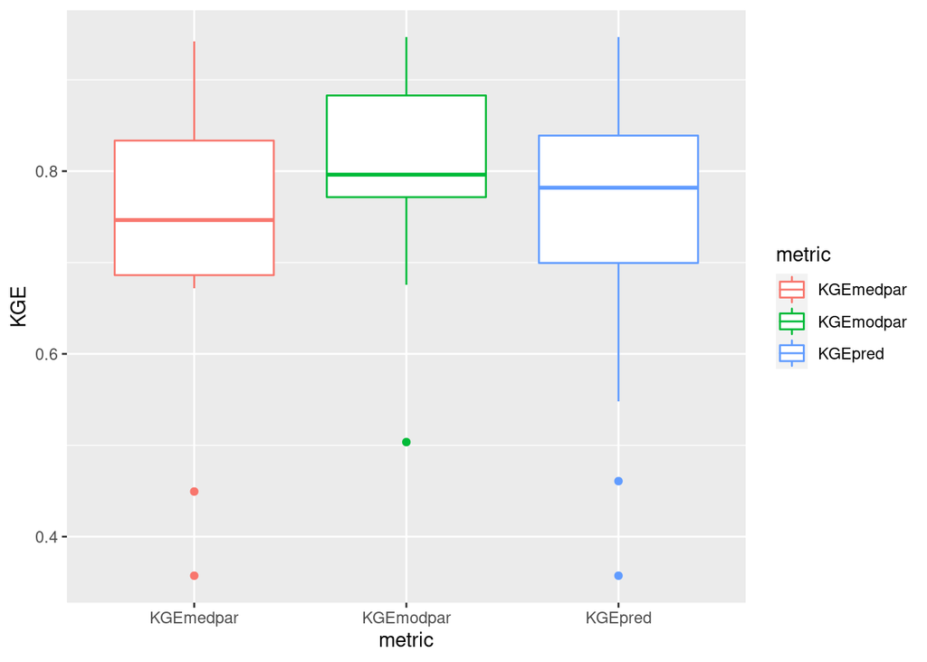

```r
avalcv_m287 <- cv287_qmly %>%
  select(-c("model", "training", "cvparams")) %>%
  group_by(.id) %>%
  #unnest(cols =  c(testing, qnat_pred)) %>%
  unnest(cols =  c(testing, qnat_pred, qnat_medpar_pred, qnat_modpar_pred)) %>%
  summarise(
    KGEpred = KGE(sim = qnat_pred, obs = qnat_obs),
    KGEmedpar = KGE(sim = qnat_medpar_pred, obs = qnat_obs),
    KGEmodpar = KGE(sim = qnat_modpar_pred, obs = qnat_obs)
  )  %>%
  #mutate(.id = factor(.id, levels = .id[order(KGEmedpar)])) %>%
  pivot_longer(
    cols = -c(.id),
    names_to = "metric",
    values_to = "valor"
  )

# avalcv_m287 %>%
# ggplot(aes(x = .id, y = valor)) +
#   geom_col() +
#   facet_wrap(~metric, scales = "free_y", nrow = data.table::uniqueN(avalcv_m287$metric)) +
#   theme(axis.text.x = )


avalcv_m287 %>%
  select(-.id, KGE = valor) %>%
  #pivot_longer(cols = -code_stn, names_to = "KGE", values_to = "valor") %>%
  ggplot(aes(metric,KGE,colour = metric)) +
  geom_boxplot()
```

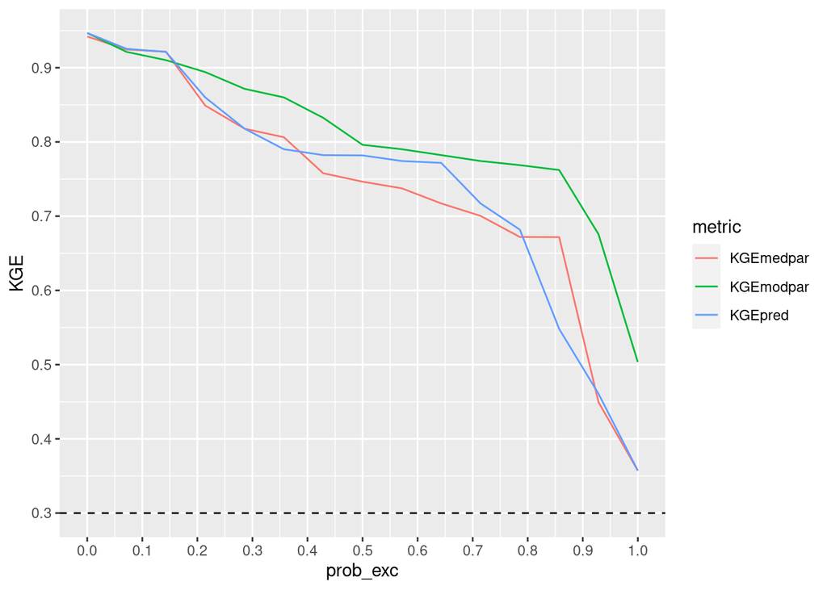

```r
# Probabilidade de excedência do KGE (Prob(KGE>=x))
avalcv_m287 %>%
 select(-.id, KGE = valor) %>%
  group_by(metric) %>%
  mutate(prob_exc = 1- percent_rank(KGE)) %>%
  mutate(prob_exc = if_else(prob_exc == 1, 0.9999, prob_exc)) %>%
  ungroup() %>%
  ggplot(aes(x = prob_exc, y = KGE, color = metric)) +
  geom_line() +
  #geom_hline(yintercept = c(-0.41, 0.3), linetype = c(3, 2)) +
  geom_hline(yintercept = c(0.3), linetype = c(2)) +
  scale_x_continuous(breaks = scales::pretty_breaks(n = 10)) +
  scale_y_continuous(breaks = scales::pretty_breaks(n = 6))
```

```r
avalcv_m287 %>%
  group_by(metric) %>%
  summarise(
    valor = mean(valor)
  )
```

```
## # A tibble: 3 x 2
##   metric    valor
##   <chr>     <dbl>
## 1 KGEmedpar 0.738
## 2 KGEmodpar 0.806
## 3 KGEpred   0.742
```

Verificaremos o desempenho do modelo utilizando os parâmetros médios no conjunto de dados de teste (aqui corresponde a apenas 1 ano).

```r
# Previsões feitas com os parâmetros médios
pcv287_medpar <- psf_cvparam(train287_qmly,
  n = 12,
  params = cv_med_params
)
pcv287_modpar <- psf_cvparam(train287_qmly,
  n = 12,
  params = cv_mod_params
)

# Previsões sem a seleção dos parâmetros
preds287_qmly <- psf_reprod(train287_qmly, n = 12)

# Previsões e observações
pobs287cv_qmly <- mutate(test287_qmly,
  qnat_pred = preds287_qmly,
  qnat_medpar_pred = pcv287_medpar,
  qnat_modpar_pred = pcv287_modpar
)

avalcvmpar_287 <- pobs287cv_qmly %>%
  summarise(
    KGE = KGE(sim = qnat_pred, obs = qnat_obs),
    KGE_medpar = KGE(sim = qnat_medpar_pred, obs = qnat_obs),
    KGE_modpar = KGE(sim = qnat_modpar_pred, obs = qnat_obs)
  )
avalcvmpar_287
```

```
## # A tibble: 1 x 3
##     KGE KGE_medpar KGE_modpar
##   <dbl>      <dbl>      <dbl>
## 1 0.781      0.824      0.781
```

Observamos, baseado na métrica KGE, uma pequena melhora no modelo utilizando a seleção dos parâmetros pela média.

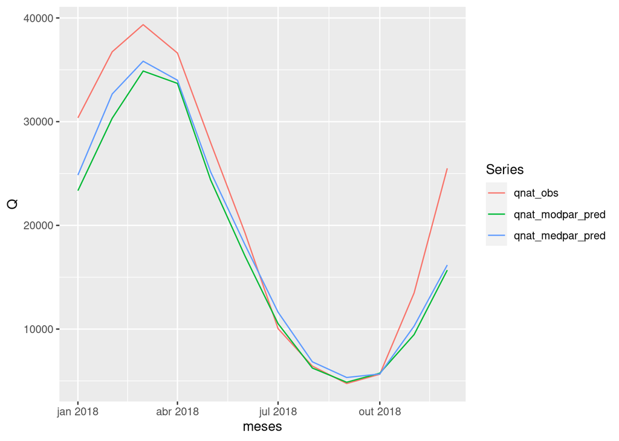

```r
posto287cv_xts <- xts(pobs287cv_qmly[,c("qnat_obs","qnat_modpar_pred","qnat_medpar_pred")],
                   order.by = as.Date(pobs287cv_qmly[["date"]]))
forecast::autoplot(posto287cv_xts, facets = FALSE)+
  ylab("Q") +
  xlab("meses") +
  theme(
    strip.background = element_blank(),
    strip.text = element_blank()
  )
```

## Validação cruzada aplicada a todos os 87 postos

```r
#postos_top10 <- c(287,295,145,281,278,291,279,99,277,190)
#qnat_mly_top10 <- filter(qnat_mly, code_stn %in% postos_top10)

# Vazão prevista
# resample_qmly <- qnat_mly_top10 %>%
#   mutate(dados = map(data, time_series_cv,
#                      initial = "30 years",  # Treinamento(seta para um valor fixo)
#                      assess = "12 months", # Validação(seta para um valor fixo)
#                      skip = "12 months",   # cada resample tem um intervalo de 12 meses
#                      cumulative = FALSE,
#                      slices_limit = n()
#   )) %>%
#   select(code_stn, dados)

set.seed(1)

resample_qmly <- qnat_mly %>%
  mutate(dados = map(data, time_series_cv,
                     #initial = "30 years",  # Treinamento(seta para um valor fixo)
                     assess = "12 months", # Validação(seta para um valor fixo)
                     skip = "12 months",   # cada resample tem um intervalo de 12 meses
                     cumulative = TRUE,    # Conj de treinamento varia
                     slice_limit = 10     # Cada resample tem 10 partições
  )) %>%
  select(code_stn, dados)
```

[output not shown]

[output cut: 32 more lines]

[output not shown]

```r
# Plano de amostragem
resample_qmlyplan <-  resample_qmly %>%
  mutate(
    dados = map(dados,tk_time_series_cv_plan)
)

# Plano de amostragem "aninhado"
resample_qmlyplan_nested <- resample_qmlyplan %>%
  mutate(dados = map(dados, ~ .x %>%
    group_by(.id, .key) %>%
    nest()))

# Plano de amostragem no formato arrumado
resample_qmlyplan_tidy <- resample_qmlyplan_nested %>%
  mutate(dados = map(dados, ~ .x %>%
    pivot_wider(names_from = .key, values_from = data)))
```

```r
if(fs::file_exists(here('output', 'cv_qmly_2methods.rds'))){

  cv_qmly <- readRDS(here("output", "cv_qmly_2methods.rds"))

} else {

  #Aplicação do algoritmo para cada partição cv do conjunto de dados de cada posto
tictoc::tic()
cv_qmly <- resample_qmlyplan_tidy %>%
  mutate(
    prev = map(dados, ~ .x %>%
      mutate(
        qnat_prev = map(
          training,
          ~ psf_reprod(.x,
            n = 12,
            predict = TRUE
          )
        ),
        model = map(
          training,
          ~ psf_reprod(.x,
            n = 12,
            predict = FALSE
          )
        )
      ))
  )

tictoc::toc()
#613.854 sec elapsed (~10 min)

# adicionando parametros dos modelos de cada slice
cv_qmly <- cv_qmly %>%
  mutate(prev = map(prev, ~ .x %>%
    ungroup() %>%
    mutate(cvparams = map(
      model,
      ~ .x %>%
        get_cvpar() #%>% flatten_int()
    ))))

## check
# cv_qmly[["prev"]][[1]]
# cv287_qmly

# Salva os resultados
saveRDS(cv_qmly, file = here('output', 'cv_qmly_2methods.rds'))

}
```

## Previsões usando a média e a moda dos parâmetros para o período de treinamento

### Moda e média dos parâmetros

```r
# Carrega os dados com modelos e previsões de cada slice
#cv_qmly <- readRDS(here("output", "cv_qmly.rds"))

cv_qmly <- cv_qmly %>%
  ungroup() %>%
  # Seleciona apenas as colunas
  select(-dados) %>%
  rename(dados = prev)

#cv_qmly[["dados"]][[1]]
#cv_qmly[["dados"]][[1]][["cvparams"]]

# Seleciona apenas as previsões e os dados de teste para a avaliação
#cv_qmly_aval <- cv_qmly %>%
#  mutate(dados = map(dados, ~ .x %>%
#                       select(-training)))

# agrupa dados por estacao
by_stn <- cv_qmly %>%
  group_by(code_stn)

# obtem a moda e a media dos parametros nas slices
by_stn <- mutate(by_stn,
  params_med = map(
    dados,
    ~ .x %>%
      select(cvparams) %>%
      map_dfr(~ .x %>% map_dfr(~.x) %>%
            summarise(across(c(k, w), ~ round(mean(.x)))))
    #%>%
    #  map(~ .x %>% summarise(across(c(k, w), ~ round(mean(.x)))))
  ),
  params_mod = map(
    dados,
    ~ .x %>%
      select(cvparams) %>%
      map_dfr(~ .x %>% map_dfr(~.x) %>%
            summarise(across(c(k, w), moda)))
    #%>%
    #  map(~ .x %>% summarise(across(c(k, w), ~ round(mean(.x)))))
  )
)

by_stn[["params_med"]]
```

```
## [[1]]
## # A tibble: 1 x 2
##       k     w
##   <dbl> <dbl>
## 1     2     4
##
## [[2]]
## # A tibble: 1 x 2
##       k     w
##   <dbl> <dbl>
## 1     2     3
##
## [[3]]
## # A tibble: 1 x 2
##       k     w
##   <dbl> <dbl>
## 1     2     4
##
## [[4]]
## # A tibble: 1 x 2
##       k     w
##   <dbl> <dbl>
## 1     2     4
##
## [[5]]
## # A tibble: 1 x 2
##       k     w
##   <dbl> <dbl>
## 1     2     3
##
## [[6]]
## # A tibble: 1 x 2
##       k     w
##   <dbl> <dbl>
## 1     2     2
##
## [[7]]
## # A tibble: 1 x 2
##       k     w
##   <dbl> <dbl>
```

[output cut: 466 more lines]

```
##       k     w
##   <dbl> <dbl>
## 1     3     3
##
## [[86]]
## # A tibble: 1 x 2
##       k     w
##   <dbl> <dbl>
## 1     2     2
##
## [[87]]
## # A tibble: 1 x 2
##       k     w
##   <dbl> <dbl>
## 1     2     2
```

```r
by_stn[["params_mod"]]
```

```
## [[1]]
## # A tibble: 1 x 2
##       k     w
##   <int> <int>
## 1     2     2
##
## [[2]]
## # A tibble: 1 x 2
##       k     w
##   <int> <int>
## 1     2     1
##
## [[3]]
## # A tibble: 1 x 2
##       k     w
##   <int> <int>
## 1     2     1
##
## [[4]]
## # A tibble: 1 x 2
##       k     w
##   <int> <int>
## 1     2     2
##
## [[5]]
## # A tibble: 1 x 2
##       k     w
##   <int> <int>
## 1     2     1
##
## [[6]]
## # A tibble: 1 x 2
##       k     w
##   <int> <int>
## 1     2     1
##
## [[7]]
## # A tibble: 1 x 2
##       k     w
##   <int> <int>
```

[output cut: 466 more lines]

```
##       k     w
##   <int> <int>
## 1     2     1
##
## [[86]]
## # A tibble: 1 x 2
##       k     w
##   <int> <int>
## 1     2     1
##
## [[87]]
## # A tibble: 1 x 2
##       k     w
##   <int> <int>
## 1     2     1
```

```r
by_stn[["dados"]][[1]]
```

```
## # A tibble: 10 x 6
##    .id     training               testing             qnat_prev  model  cvparams
##    <chr>   <list>                 <list>              <list>     <list> <list>
##  1 Slice01 <tibble[,2] [1,044 × … <tibble[,2] [12 × … <dbl [12]> <psf>  <int [2…
##  2 Slice02 <tibble[,2] [1,032 × … <tibble[,2] [12 × … <dbl [12]> <psf>  <int [2…
##  3 Slice03 <tibble[,2] [1,020 × … <tibble[,2] [12 × … <dbl [12]> <psf>  <int [2…
##  4 Slice04 <tibble[,2] [1,008 × … <tibble[,2] [12 × … <dbl [12]> <psf>  <int [2…
##  5 Slice05 <tibble[,2] [996 × 2]> <tibble[,2] [12 × … <dbl [12]> <psf>  <int [2…
##  6 Slice06 <tibble[,2] [984 × 2]> <tibble[,2] [12 × … <dbl [12]> <psf>  <int [2…
##  7 Slice07 <tibble[,2] [972 × 2]> <tibble[,2] [12 × … <dbl [12]> <psf>  <int [2…
##  8 Slice08 <tibble[,2] [960 × 2]> <tibble[,2] [12 × … <dbl [12]> <psf>  <int [2…
##  9 Slice09 <tibble[,2] [948 × 2]> <tibble[,2] [12 × … <dbl [12]> <psf>  <int [2…
## 10 Slice10 <tibble[,2] [936 × 2]> <tibble[,2] [12 × … <dbl [12]> <psf>  <int [2…
```

### Previsões para o período teste

```r
tictoc::tic()

preds_test <- map_df(
  by_stn$code_stn,
  function(icode) {
    # icode = 6
    data_stn <- filter(by_stn, code_stn == icode)

    pars_med <- unlist(data_stn$params_med)
    pars_mod <- unlist(data_stn$params_mod)

    data <- data_stn %>%
      ungroup() %>%
      select(dados) %>%
      unnest(dados) %>%
      mutate(
        code_stn = icode,
        preds_med = map(
          training,
          ~ .x %>% psf_cvparam(n = 12, params = pars_med)
        ),
        preds_mod = map(
          training,
          ~ .x %>% psf_cvparam(n = 12, params = pars_mod)
        )
      ) %>%
      relocate(code_stn)
  }
)
tictoc::toc()
```

```
## 36.738 sec elapsed
```

```r
# 36.773 sec elapsed
preds_test
```

```
## # A tibble: 870 x 9
##    code_stn .id    training testing qnat_prev model cvparams preds_med preds_mod
##       <dbl> <chr>  <list>   <list>  <list>    <lis> <list>   <list>    <list>
##  1        6 Slice… <tibble… <tibbl… <dbl [12… <psf> <int [2… <dbl [12… <dbl [12…
##  2        6 Slice… <tibble… <tibbl… <dbl [12… <psf> <int [2… <dbl [12… <dbl [12…
##  3        6 Slice… <tibble… <tibbl… <dbl [12… <psf> <int [2… <dbl [12… <dbl [12…
##  4        6 Slice… <tibble… <tibbl… <dbl [12… <psf> <int [2… <dbl [12… <dbl [12…
##  5        6 Slice… <tibble… <tibbl… <dbl [12… <psf> <int [2… <dbl [12… <dbl [12…
##  6        6 Slice… <tibble… <tibbl… <dbl [12… <psf> <int [2… <dbl [12… <dbl [12…
##  7        6 Slice… <tibble… <tibbl… <dbl [12… <psf> <int [2… <dbl [12… <dbl [12…
##  8        6 Slice… <tibble… <tibbl… <dbl [12… <psf> <int [2… <dbl [12… <dbl [12…
##  9        6 Slice… <tibble… <tibbl… <dbl [12… <psf> <int [2… <dbl [12… <dbl [12…
## 10        6 Slice… <tibble… <tibbl… <dbl [12… <psf> <int [2… <dbl [12… <dbl [12…
## # … with 860 more rows
```

### Avaliação

Cálculo do KGE para as previsões de cada slice.

```r
cv_aval <- preds_test %>%
  select(code_stn, testing, contains("preds_")) %>%
  # 870 (10 slices x 87 stns) x 12 meses (periodo teste)
  unnest(cols = c(testing, preds_med, preds_mod)) %>%
  group_by(code_stn) %>%
  summarise(
      KGE_parsmed = KGE(sim = preds_med, obs = qnat_obs),
      KGE_parsmod = KGE(sim = preds_mod, obs = qnat_obs)
    )
cv_aval_long <- cv_aval %>%
  pivot_longer(cols = -code_stn, names_to = "metric", values_to = "KGE") %>%
  mutate(metric = str_replace_all(metric, "KGE_", ""))
```

Gráficos do KGE

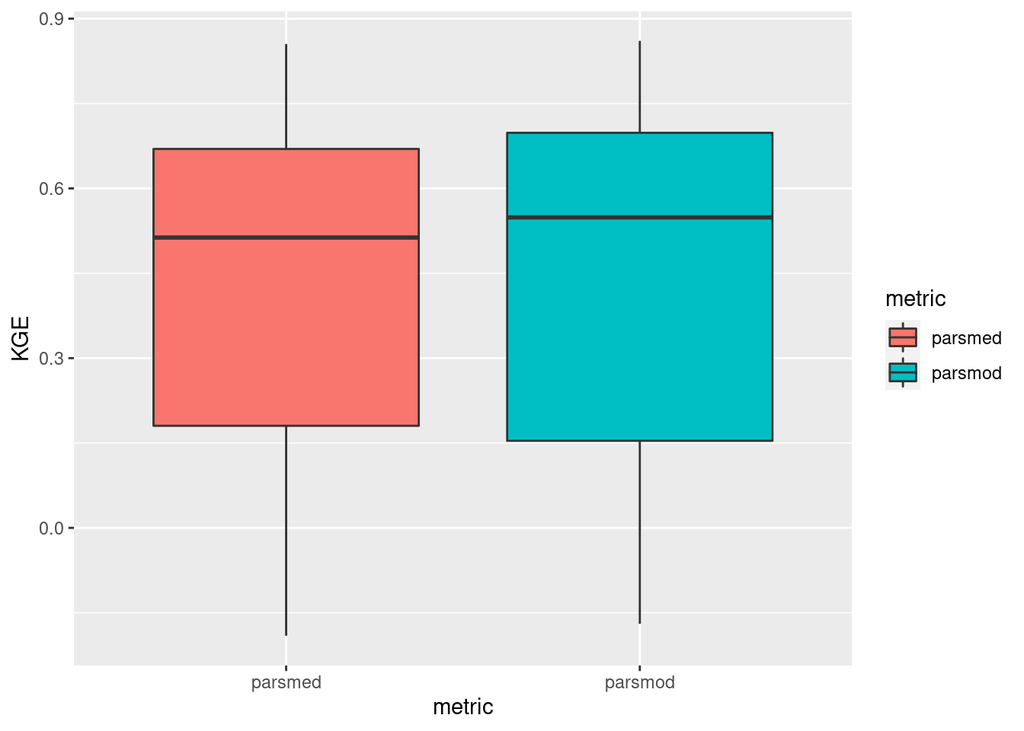

```r
bxplot_kge <- cv_aval_long %>%
  #pivot_longer(cols = -code_stn, names_to = "KGE", values_to = "valor") %>%
  ggplot(aes(metric, KGE, fill = metric)) +
  geom_boxplot()
bxplot_kge
```

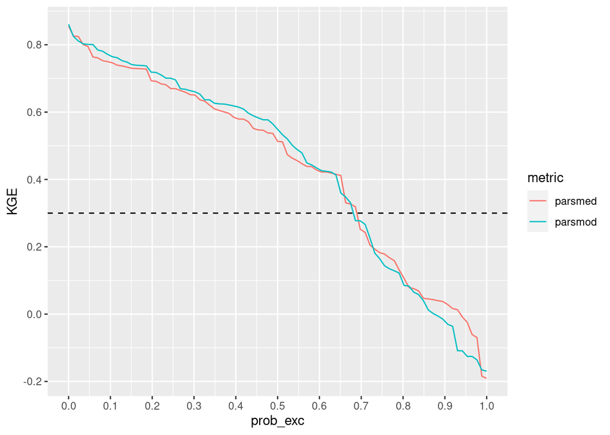

```r
# Probabilidade de excedência do KGE (Prob(KGE>=x))
plot_pexc <- cv_aval_long %>%
  arrange(metric) %>%
  group_by(metric) %>%
  mutate(prob_exc = 1- percent_rank(KGE)) %>%
  mutate(prob_exc = if_else(prob_exc == 1, 0.9999, prob_exc)) %>%
  ungroup() %>%
  ggplot(aes(x = prob_exc, y = KGE, color = metric)) +
  geom_line() +
  #geom_hline(yintercept = c(-0.41, 0.3), linetype = c(3, 2)) +
  geom_hline(yintercept = c(0.3), linetype = c(2)) +
  scale_x_continuous(breaks = scales::pretty_breaks(n = 10)) +
  scale_y_continuous(breaks = scales::pretty_breaks(n = 6))
plot_pexc
```